# import pandas as pd

data=pd.read_csv(r"C:\Users\JAYESH KUMAR\Downloads\8. Netflix Dataset.csv")

# NETFLIX PROJECT

```python
import pandas as pd
```

```python
data=pd.read_csv(r"C:\Users\JAYESH KUMAR\Downloads\8. Netflix Dataset.csv")
```

```python
data
```

|  | Show_Id | Category | Title | Director | Cast | Country | Release_Date | Rating | Duration | Type | Description |
| --- | --- | --- | --- | --- | --- | --- | --- | --- | --- | --- | --- |
| 0 | s1 | TV Show | 3% | NaN | João Miguel, Bianca Comparato, Michel Gomes, R... | Brazil | August 14, 2020 | TV-MA | 4 Seasons | International TV Shows, TV Dramas, TV Sci-Fi &... | In a future where the elite inhabit an island ... |
| 1 | s2 | Movie | 07:19 | Jorge Michel Grau | Demián Bichir, Héctor Bonilla, Oscar Serrano, ... | Mexico | December 23, 2016 | TV-MA | 93 min | Dramas, International Movies | After a devastating earthquake hits Mexico Cit... |
| 2 | s3 | Movie | 23:59 | Gilbert Chan | Tedd Chan, Stella Chung, Henley Hii, Lawrence ... | Singapore | December 20, 2018 | R | 78 min | Horror Movies, International Movies | When an army recruit is found dead, his fellow... |
| 3 | s4 | Movie | 9 | Shane Acker | Elijah Wood, John C. Reilly, Jennifer Connelly... | United States | November 16, 2017 | PG-13 | 80 min | Action & Adventure, Independent Movies, Sci-Fi... | In a postapocalyptic world, rag-doll robots hi... |
| 4 | s5 | Movie | 21 | Robert Luketic | Jim Sturgess, Kevin Spacey, Kate Bosworth, Aar... | United States | January 1, 2020 | PG-13 | 123 min | Dramas | A brilliant group of students become card-coun... |
| ... | ... | ... | ... | ... | ... | ... | ... | ... | ... | ... | ... |
| 7784 | s7783 | Movie | Zozo | Josef Fares | Imad Creidi, Antoinette Turk, Elias Gergi, Car... | Sweden, Czech Republic, United Kingdom, Denmar... | October 19, 2020 | TV-MA | 99 min | Dramas, International Movies | When Lebanon's Civil War deprives Zozo of his ... |
| 7785 | s7784 | Movie | Zubaan | Mozez Singh | Vicky Kaushal, Sarah-Jane Dias, Raaghav Chanan... | India | March 2, 2019 | TV-14 | 111 min | Dramas, International Movies, Music & Musicals | A scrappy but poor boy worms his way into a ty... |
| 7786 | s7785 | Movie | Zulu Man in Japan | NaN | Nasty C | NaN | September 25, 2020 | TV-MA | 44 min | Documentaries, International Movies, Music & M... | In this documentary, South African rapper Nast... |
| 7787 | s7786 | TV Show | Zumbo's Just Desserts | NaN | Adriano Zumbo, Rachel Khoo | Australia | October 31, 2020 | TV-PG | 1 Season | International TV Shows, Reality TV | Dessert wizard Adriano Zumbo looks for the nex... |
| 7788 | s7787 | Movie | ZZ TOP: THAT LITTLE OL' BAND FROM TEXAS | Sam Dunn | NaN | United Kingdom, Canada, United States | March 1, 2020 | TV-MA | 90 min | Documentaries, Music & Musicals | This documentary delves into the mystique behi... |

7789 rows × 11 columns

```python
data.head()
```

|  | Show_Id | Category | Title | Director | Cast | Country | Release_Date | Rating | Duration | Type | Description |
| --- | --- | --- | --- | --- | --- | --- | --- | --- | --- | --- | --- |
| 0 | s1 | TV Show | 3% | NaN | João Miguel, Bianca Comparato, Michel Gomes, R... | Brazil | August 14, 2020 | TV-MA | 4 Seasons | International TV Shows, TV Dramas, TV Sci-Fi &... | In a future where the elite inhabit an island ... |
| 1 | s2 | Movie | 07:19 | Jorge Michel Grau | Demián Bichir, Héctor Bonilla, Oscar Serrano, ... | Mexico | December 23, 2016 | TV-MA | 93 min | Dramas, International Movies | After a devastating earthquake hits Mexico Cit... |
| 2 | s3 | Movie | 23:59 | Gilbert Chan | Tedd Chan, Stella Chung, Henley Hii, Lawrence ... | Singapore | December 20, 2018 | R | 78 min | Horror Movies, International Movies | When an army recruit is found dead, his fellow... |
| 3 | s4 | Movie | 9 | Shane Acker | Elijah Wood, John C. Reilly, Jennifer Connelly... | United States | November 16, 2017 | PG-13 | 80 min | Action & Adventure, Independent Movies, Sci-Fi... | In a postapocalyptic world, rag-doll robots hi... |
| 4 | s5 | Movie | 21 | Robert Luketic | Jim Sturgess, Kevin Spacey, Kate Bosworth, Aar... | United States | January 1, 2020 | PG-13 | 123 min | Dramas | A brilliant group of students become card-coun... |

```python
data.tail()
```

|  | Show_Id | Category | Title | Director | Cast | Country | Release_Date | Rating | Duration | Type | Description |
| --- | --- | --- | --- | --- | --- | --- | --- | --- | --- | --- | --- |
| 7784 | s7783 | Movie | Zozo | Josef Fares | Imad Creidi, Antoinette Turk, Elias Gergi, Car... | Sweden, Czech Republic, United Kingdom, Denmar... | October 19, 2020 | TV-MA | 99 min | Dramas, International Movies | When Lebanon's Civil War deprives Zozo of his ... |
| 7785 | s7784 | Movie | Zubaan | Mozez Singh | Vicky Kaushal, Sarah-Jane Dias, Raaghav Chanan... | India | March 2, 2019 | TV-14 | 111 min | Dramas, International Movies, Music & Musicals | A scrappy but poor boy worms his way into a ty... |
| 7786 | s7785 | Movie | Zulu Man in Japan | NaN | Nasty C | NaN | September 25, 2020 | TV-MA | 44 min | Documentaries, International Movies, Music & M... | In this documentary, South African rapper Nast... |
| 7787 | s7786 | TV Show | Zumbo's Just Desserts | NaN | Adriano Zumbo, Rachel Khoo | Australia | October 31, 2020 | TV-PG | 1 Season | International TV Shows, Reality TV | Dessert wizard Adriano Zumbo looks for the nex... |
| 7788 | s7787 | Movie | ZZ TOP: THAT LITTLE OL' BAND FROM TEXAS | Sam Dunn | NaN | United Kingdom, Canada, United States | March 1, 2020 | TV-MA | 90 min | Documentaries, Music & Musicals | This documentary delves into the mystique behi... |

```python
data.shape
```

```
(7789, 11)
```

```python
data.size
```

```
85679
```

```python
data.columns
```

```
Index(['Show_Id', 'Category', 'Title', 'Director', 'Cast', 'Country',
       'Release_Date', 'Rating', 'Duration', 'Type', 'Description'],
      dtype='object')
```

```python
data.dtypes
```

```
Show_Id         object
Category        object
Title           object
Director        object
Cast            object
Country         object
Release_Date    object
Rating          object
Duration        object
Type            object
Description     object
dtype: object
```

```python
data.info()
```

```
<class 'pandas.core.frame.DataFrame'>
RangeIndex: 7789 entries, 0 to 7788
Data columns (total 11 columns):
 #   Column        Non-Null Count  Dtype
---  ------        --------------  -----
 0   Show_Id       7789 non-null   object
 1   Category      7789 non-null   object
 2   Title         7789 non-null   object
 3   Director      5401 non-null   object
 4   Cast          7071 non-null   object
 5   Country       7282 non-null   object
 6   Release_Date  7779 non-null   object
 7   Rating        7782 non-null   object
 8   Duration      7789 non-null   object
 9   Type          7789 non-null   object
 10  Description   7789 non-null   object
dtypes: object(11)
memory usage: 669.5+ KB
```

# Is there any duplicate record in this data set? If yes then remove:

```python
data.head()
```

|  | Show_Id | Category | Title | Director | Cast | Country | Release_Date | Rating | Duration | Type | Description |
| --- | --- | --- | --- | --- | --- | --- | --- | --- | --- | --- | --- |
| 0 | s1 | TV Show | 3% | NaN | João Miguel, Bianca Comparato, Michel Gomes, R... | Brazil | August 14, 2020 | TV-MA | 4 Seasons | International TV Shows, TV Dramas, TV Sci-Fi &... | In a future where the elite inhabit an island ... |
| 1 | s2 | Movie | 07:19 | Jorge Michel Grau | Demián Bichir, Héctor Bonilla, Oscar Serrano, ... | Mexico | December 23, 2016 | TV-MA | 93 min | Dramas, International Movies | After a devastating earthquake hits Mexico Cit... |
| 2 | s3 | Movie | 23:59 | Gilbert Chan | Tedd Chan, Stella Chung, Henley Hii, Lawrence ... | Singapore | December 20, 2018 | R | 78 min | Horror Movies, International Movies | When an army recruit is found dead, his fellow... |
| 3 | s4 | Movie | 9 | Shane Acker | Elijah Wood, John C. Reilly, Jennifer Connelly... | United States | November 16, 2017 | PG-13 | 80 min | Action & Adventure, Independent Movies, Sci-Fi... | In a postapocalyptic world, rag-doll robots hi... |
| 4 | s5 | Movie | 21 | Robert Luketic | Jim Sturgess, Kevin Spacey, Kate Bosworth, Aar... | United States | January 1, 2020 | PG-13 | 123 min | Dramas | A brilliant group of students become card-coun... |

```python
data.shape
```

```
(7789, 11)
```

```python
data[data.duplicated()]
```

|  | Show_Id | Category | Title | Director | Cast | Country | Release_Date | Rating | Duration | Type | Description |
| --- | --- | --- | --- | --- | --- | --- | --- | --- | --- | --- | --- |
| 6300 | s684 | Movie | Backfire | Dave Patten | Black Deniro, Byron "Squally" Vinson, Dominic ... | United States | April 5, 2019 | TV-MA | 97 min | Dramas, Independent Movies, Thrillers | When two would-be robbers accidentally kill a ... |
| 6622 | s6621 | Movie | The Lost Okoroshi | Abba T. Makama | Seun Ajayi, Judith Audu, Tope Tedela, Ifu Enna... | Nigeria | September 4, 2020 | TV-MA | 94 min | Comedies, Dramas, Independent Movies | A disillusioned security guard transforms into... |

```python
data.drop_duplicates(inplace=True)
```

```python
data[data.duplicated()]
```

|  | Show_Id | Category | Title | Director | Cast | Country | Release_Date | Rating | Duration | Type | Description |
| --- | --- | --- | --- | --- | --- | --- | --- | --- | --- | --- | --- |

```python
data.shape
```

```
(7787, 11)
```

# Is there any null value in column then show it with heat-map:

```python
data.head()
```

|  | Show_Id | Category | Title | Director | Cast | Country | Release_Date | Rating | Duration | Type | Description |
| --- | --- | --- | --- | --- | --- | --- | --- | --- | --- | --- | --- |
| 0 | s1 | TV Show | 3% | NaN | João Miguel, Bianca Comparato, Michel Gomes, R... | Brazil | August 14, 2020 | TV-MA | 4 Seasons | International TV Shows, TV Dramas, TV Sci-Fi &... | In a future where the elite inhabit an island ... |
| 1 | s2 | Movie | 07:19 | Jorge Michel Grau | Demián Bichir, Héctor Bonilla, Oscar Serrano, ... | Mexico | December 23, 2016 | TV-MA | 93 min | Dramas, International Movies | After a devastating earthquake hits Mexico Cit... |
| 2 | s3 | Movie | 23:59 | Gilbert Chan | Tedd Chan, Stella Chung, Henley Hii, Lawrence ... | Singapore | December 20, 2018 | R | 78 min | Horror Movies, International Movies | When an army recruit is found dead, his fellow... |
| 3 | s4 | Movie | 9 | Shane Acker | Elijah Wood, John C. Reilly, Jennifer Connelly... | United States | November 16, 2017 | PG-13 | 80 min | Action & Adventure, Independent Movies, Sci-Fi... | In a postapocalyptic world, rag-doll robots hi... |
| 4 | s5 | Movie | 21 | Robert Luketic | Jim Sturgess, Kevin Spacey, Kate Bosworth, Aar... | United States | January 1, 2020 | PG-13 | 123 min | Dramas | A brilliant group of students become card-coun... |

```python
data.isnull()
```

|  | Show_Id | Category | Title | Director | Cast | Country | Release_Date | Rating | Duration | Type | Description |
| --- | --- | --- | --- | --- | --- | --- | --- | --- | --- | --- | --- |
| 0 | False | False | False | True | False | False | False | False | False | False | False |
| 1 | False | False | False | False | False | False | False | False | False | False | False |
| 2 | False | False | False | False | False | False | False | False | False | False | False |
| 3 | False | False | False | False | False | False | False | False | False | False | False |
| 4 | False | False | False | False | False | False | False | False | False | False | False |
| ... | ... | ... | ... | ... | ... | ... | ... | ... | ... | ... | ... |
| 7784 | False | False | False | False | False | False | False | False | False | False | False |
| 7785 | False | False | False | False | False | False | False | False | False | False | False |
| 7786 | False | False | False | True | False | True | False | False | False | False | False |
| 7787 | False | False | False | True | False | False | False | False | False | False | False |
| 7788 | False | False | False | False | True | False | False | False | False | False | False |

7787 rows × 11 columns

```python
data.isnull().sum()
```

```
Show_Id            0
Category           0
Title              0
Director        2388
Cast             718
Country          507
Release_Date      10
Rating             7
Duration           0
Type               0
Description        0
dtype: int64
```

# seaborn library (heat-map)

```python
import seaborn as sns
```

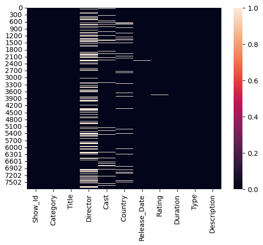

```python
sns.heatmap(data.isnull())
```

# for 'house of cards' that is the show id and who is the director of the show?

isin()

```python
data.head()
```

|  | Show_Id | Category | Title | Director | Cast | Country | Release_Date | Rating | Duration | Type | Description |
| --- | --- | --- | --- | --- | --- | --- | --- | --- | --- | --- | --- |
| 0 | s1 | TV Show | 3% | NaN | João Miguel, Bianca Comparato, Michel Gomes, R... | Brazil | August 14, 2020 | TV-MA | 4 Seasons | International TV Shows, TV Dramas, TV Sci-Fi &... | In a future where the elite inhabit an island ... |
| 1 | s2 | Movie | 07:19 | Jorge Michel Grau | Demián Bichir, Héctor Bonilla, Oscar Serrano, ... | Mexico | December 23, 2016 | TV-MA | 93 min | Dramas, International Movies | After a devastating earthquake hits Mexico Cit... |
| 2 | s3 | Movie | 23:59 | Gilbert Chan | Tedd Chan, Stella Chung, Henley Hii, Lawrence ... | Singapore | December 20, 2018 | R | 78 min | Horror Movies, International Movies | When an army recruit is found dead, his fellow... |
| 3 | s4 | Movie | 9 | Shane Acker | Elijah Wood, John C. Reilly, Jennifer Connelly... | United States | November 16, 2017 | PG-13 | 80 min | Action & Adventure, Independent Movies, Sci-Fi... | In a postapocalyptic world, rag-doll robots hi... |
| 4 | s5 | Movie | 21 | Robert Luketic | Jim Sturgess, Kevin Spacey, Kate Bosworth, Aar... | United States | January 1, 2020 | PG-13 | 123 min | Dramas | A brilliant group of students become card-coun... |

```python
data[data["Title"].isin(["House of Cards"])]
```

|  | Show_Id | Category | Title | Director | Cast | Country | Release_Date | Rating | Duration | Type | Description |
| --- | --- | --- | --- | --- | --- | --- | --- | --- | --- | --- | --- |
| 2832 | s2833 | TV Show | House of Cards | Robin Wright, David Fincher, Gerald McRaney, J... | Kevin Spacey, Robin Wright, Kate Mara, Corey S... | United States | November 2, 2018 | TV-MA | 6 Seasons | TV Dramas, TV Thrillers | A ruthless politician will stop at nothing to ... |

# str.contains()

```python
data[data["Title"].str.contains("House of Cards")]
```

|  | Show_Id | Category | Title | Director | Cast | Country | Release_Date | Rating | Duration | Type | Description |
| --- | --- | --- | --- | --- | --- | --- | --- | --- | --- | --- | --- |
| 2832 | s2833 | TV Show | House of Cards | Robin Wright, David Fincher, Gerald McRaney, J... | Kevin Spacey, Robin Wright, Kate Mara, Corey S... | United States | November 2, 2018 | TV-MA | 6 Seasons | TV Dramas, TV Thrillers | A ruthless politician will stop at nothing to ... |

# in wch year highest no of the TV shows & movie were realeased? show with Bar graph.

```python
data.dtypes
```

```
Show_Id         object
Category        object
Title           object
Director        object
Cast            object
Country         object
Release_Date    object
Rating          object
Duration        object
Type            object
Description     object
dtype: object
```

```python
data['Date_N']=pd.to_datetime(data['Release_Date'])
```

```python
data.head()
```

|  | Show_Id | Category | Title | Director | Cast | Country | Release_Date | Rating | Duration | Type | Description | Date_N |
| --- | --- | --- | --- | --- | --- | --- | --- | --- | --- | --- | --- | --- |
| 0 | s1 | TV Show | 3% | NaN | João Miguel, Bianca Comparato, Michel Gomes, R... | Brazil | August 14, 2020 | TV-MA | 4 Seasons | International TV Shows, TV Dramas, TV Sci-Fi &... | In a future where the elite inhabit an island ... | 2020-08-14 |
| 1 | s2 | Movie | 07:19 | Jorge Michel Grau | Demián Bichir, Héctor Bonilla, Oscar Serrano, ... | Mexico | December 23, 2016 | TV-MA | 93 min | Dramas, International Movies | After a devastating earthquake hits Mexico Cit... | 2016-12-23 |
| 2 | s3 | Movie | 23:59 | Gilbert Chan | Tedd Chan, Stella Chung, Henley Hii, Lawrence ... | Singapore | December 20, 2018 | R | 78 min | Horror Movies, International Movies | When an army recruit is found dead, his fellow... | 2018-12-20 |
| 3 | s4 | Movie | 9 | Shane Acker | Elijah Wood, John C. Reilly, Jennifer Connelly... | United States | November 16, 2017 | PG-13 | 80 min | Action & Adventure, Independent Movies, Sci-Fi... | In a postapocalyptic world, rag-doll robots hi... | 2017-11-16 |
| 4 | s5 | Movie | 21 | Robert Luketic | Jim Sturgess, Kevin Spacey, Kate Bosworth, Aar... | United States | January 1, 2020 | PG-13 | 123 min | Dramas | A brilliant group of students become card-coun... | 2020-01-01 |

```python
data.dtypes
```

```
Show_Id                 object
Category                object
Title                   object
Director                object
Cast                    object
Country                 object
Release_Date            object
Rating                  object
Duration                object
Type                    object
Description             object
Date_N          datetime64[ns]
dtype: object
```

# dt.years.value_counts()

```python
data["Date_N"].dt.year.value_counts()
```

```
2019.0    2153
2020.0    2009
2018.0    1685
2017.0    1225
2016.0     443
2021.0     117
2015.0      88
2014.0      25
2011.0      13
2013.0      11
2012.0       3
2008.0       2
2009.0       2
2010.0       1
Name: Date_N, dtype: int64
```

# Bar Graph

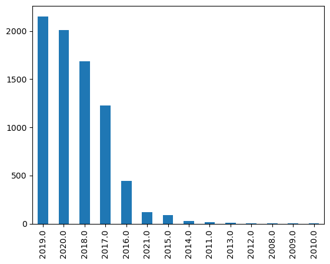

```python
data["Date_N"].dt.year.value_counts().plot(kind='bar')
```

# How many Tv shows are in the dataset?show with bar graph.

```python
#groupby
```

```python
data.head(2)
```

|  | Show_Id | Category | Title | Director | Cast | Country | Release_Date | Rating | Duration | Type | Description | Date_N |
| --- | --- | --- | --- | --- | --- | --- | --- | --- | --- | --- | --- | --- |
| 0 | s1 | TV Show | 3% | NaN | João Miguel, Bianca Comparato, Michel Gomes, R... | Brazil | August 14, 2020 | TV-MA | 4 Seasons | International TV Shows, TV Dramas, TV Sci-Fi &... | In a future where the elite inhabit an island ... | 2020-08-14 |
| 1 | s2 | Movie | 07:19 | Jorge Michel Grau | Demián Bichir, Héctor Bonilla, Oscar Serrano, ... | Mexico | December 23, 2016 | TV-MA | 93 min | Dramas, International Movies | After a devastating earthquake hits Mexico Cit... | 2016-12-23 |

```python
data.groupby('Category').Category.count()
```

```
Category
Movie      5377
TV Show    2410
Name: Category, dtype: int64
```

# countplot()

[figure not shown]

```python
sns.countplot()
```

# show all the movies that were realeased in the year 2000

# Creating new column

```python
data.head(2)
```

|  | Show_Id | Category | Title | Director | Cast | Country | Release_Date | Rating | Duration | Type | Description | Date_N |
| --- | --- | --- | --- | --- | --- | --- | --- | --- | --- | --- | --- | --- |
| 0 | s1 | TV Show | 3% | NaN | João Miguel, Bianca Comparato, Michel Gomes, R... | Brazil | August 14, 2020 | TV-MA | 4 Seasons | International TV Shows, TV Dramas, TV Sci-Fi &... | In a future where the elite inhabit an island ... | 2020-08-14 |
| 1 | s2 | Movie | 07:19 | Jorge Michel Grau | Demián Bichir, Héctor Bonilla, Oscar Serrano, ... | Mexico | December 23, 2016 | TV-MA | 93 min | Dramas, International Movies | After a devastating earthquake hits Mexico Cit... | 2016-12-23 |

```python
data['Year']=data['Date_N'].dt.year
```

```python
data.head(2)
```

|  | Show_Id | Category | Title | Director | Cast | Country | Release_Date | Rating | Duration | Type | Description | Date_N | Year |
| --- | --- | --- | --- | --- | --- | --- | --- | --- | --- | --- | --- | --- | --- |
| 0 | s1 | TV Show | 3% | NaN | João Miguel, Bianca Comparato, Michel Gomes, R... | Brazil | August 14, 2020 | TV-MA | 4 Seasons | International TV Shows, TV Dramas, TV Sci-Fi &... | In a future where the elite inhabit an island ... | 2020-08-14 | 2020.0 |
| 1 | s2 | Movie | 07:19 | Jorge Michel Grau | Demián Bichir, Héctor Bonilla, Oscar Serrano, ... | Mexico | December 23, 2016 | TV-MA | 93 min | Dramas, International Movies | After a devastating earthquake hits Mexico Cit... | 2016-12-23 | 2016.0 |

# Filtering

```python
data[ (data['Category']== 'Movie') & (data['Year']==2000) ]
```

[output not shown]

```python
data[ (data['Category']== 'Movie') & (data['Year']==2020) ]
```

[output not shown]

1312 rows × 14 columns

# Show only the titles of all TV shows that wre realesed in India only

value_counts()

```python
data.head(2)
```

|  | Show_Id | Category | Title | Director | Cast | Country | Release_Date | Rating | Duration | Type | Description | Date_N | Year | Month |
| --- | --- | --- | --- | --- | --- | --- | --- | --- | --- | --- | --- | --- | --- | --- |
| 0 | s1 | TV Show | 3% | NaN | João Miguel, Bianca Comparato, Michel Gomes, R... | Brazil | August 14, 2020 | TV-MA | 4 Seasons | International TV Shows, TV Dramas, TV Sci-Fi &... | In a future where the elite inhabit an island ... | 2020-08-14 | 2020.0 | 8.0 |
| 1 | s2 | Movie | 07:19 | Jorge Michel Grau | Demián Bichir, Héctor Bonilla, Oscar Serrano, ... | Mexico | December 23, 2016 | TV-MA | 93 min | Dramas, International Movies | After a devastating earthquake hits Mexico Cit... | 2016-12-23 | 2016.0 | 12.0 |

```python
data[ (data['Category']=='TV Show') & (data['Country']=='India') ] ['Title']
```

```
86            21 Sarfarosh: Saragarhi 1897
132                              7 (Seven)
340                           Agent Raghav
364                           Akbar Birbal
533                    Anjaan: Rural Myths
                       ...
6249                  The Creative Indians
6400    The Golden Years with Javed Akhtar
6469                The House That Made Me
7294                            Typewriter
7705                       Yeh Meri Family
Name: Title, Length: 71, dtype: object
```

[output not shown]

# Show top 10 directors who gave the highest no of tv shows & movie netflix

value_counts()

```python
data.head(2)
```

|  | Show_Id | Category | Title | Director | Cast | Country | Release_Date | Rating | Duration | Type | Description | Date_N | Year | Month |
| --- | --- | --- | --- | --- | --- | --- | --- | --- | --- | --- | --- | --- | --- | --- |
| 0 | s1 | TV Show | 3% | NaN | João Miguel, Bianca Comparato, Michel Gomes, R... | Brazil | August 14, 2020 | TV-MA | 4 Seasons | International TV Shows, TV Dramas, TV Sci-Fi &... | In a future where the elite inhabit an island ... | 2020-08-14 | 2020.0 | 8.0 |
| 1 | s2 | Movie | 07:19 | Jorge Michel Grau | Demián Bichir, Héctor Bonilla, Oscar Serrano, ... | Mexico | December 23, 2016 | TV-MA | 93 min | Dramas, International Movies | After a devastating earthquake hits Mexico Cit... | 2016-12-23 | 2016.0 | 12.0 |

```python
data['Director'].value_counts()
```

```
Raúl Campos, Jan Suter    18
Marcus Raboy              16
Jay Karas                 14
Cathy Garcia-Molina       13
Jay Chapman               12
                          ..
Vibhu Virender Puri        1
Lucien Jean-Baptiste       1
Jason Krawczyk             1
Quinn Lasher               1
Sam Dunn                   1
Name: Director, Length: 4050, dtype: int64
```

# show all the records were category is movie n type is comedies or country is united kngdom

filtering(and,or operators)

```python
data.head(2)
```

|  | Show_Id | Category | Title | Director | Cast | Country | Release_Date | Rating | Duration | Type | Description | Date_N | Year | Month |
| --- | --- | --- | --- | --- | --- | --- | --- | --- | --- | --- | --- | --- | --- | --- |
| 0 | s1 | TV Show | 3% | NaN | João Miguel, Bianca Comparato, Michel Gomes, R... | Brazil | August 14, 2020 | TV-MA | 4 Seasons | International TV Shows, TV Dramas, TV Sci-Fi &... | In a future where the elite inhabit an island ... | 2020-08-14 | 2020.0 | 8.0 |
| 1 | s2 | Movie | 07:19 | Jorge Michel Grau | Demián Bichir, Héctor Bonilla, Oscar Serrano, ... | Mexico | December 23, 2016 | TV-MA | 93 min | Dramas, International Movies | After a devastating earthquake hits Mexico Cit... | 2016-12-23 | 2016.0 | 12.0 |

```python
data[(data['Category']=='Movie') & (data["Type"]=='Comedies')]
```

|  | Show_Id | Category | Title | Director | Cast | Country | Release_Date | Rating | Duration | Type | Description | Date_N | Year | Month |
| --- | --- | --- | --- | --- | --- | --- | --- | --- | --- | --- | --- | --- | --- | --- |
| 33 | s34 | Movie | #realityhigh | Fernando Lebrija | Nesta Cooper, Kate Walsh, John Michael Higgins... | United States | September 8, 2017 | TV-14 | 99 min | Comedies | When nerdy high schooler Dani finally attracts... | 2017-09-08 | 2017.0 | 9.0 |
| 72 | s73 | Movie | 17 Again | Burr Steers | Zac Efron, Leslie Mann, Matthew Perry, Thomas ... | United States | January 1, 2021 | PG-13 | 102 min | Comedies | Nearing a midlife crisis, thirty-something Mik... | 2021-01-01 | 2021.0 | 1.0 |
| 84 | s85 | Movie | 21 & Over | Jon Lucas, Scott Moore | Miles Teller, Skylar Astin, Justin Chon, Sarah... | United States | April 16, 2019 | R | 93 min | Comedies | Jeff's straight-and-narrow life changes abrupt... | 2019-04-16 | 2019.0 | 4.0 |
| 148 | s149 | Movie | A Bad Moms Christmas | Jon Lucas, Scott Moore | Mila Kunis, Kristen Bell, Kathryn Hahn, Susan ... | United States, China | February 14, 2020 | R | 104 min | Comedies | Stressed-out moms Amy, Carla and Kiki are back... | 2020-02-14 | 2020.0 | 2.0 |
| 174 | s175 | Movie | A Futile and Stupid Gesture | David Wain | Will Forte, Domhnall Gleeson, Martin Mull, Joe... | United States | January 26, 2018 | TV-MA | 102 min | Comedies | In a brief life full of triumph and failure, "... | 2018-01-26 | 2018.0 | 1.0 |
| ... | ... | ... | ... | ... | ... | ... | ... | ... | ... | ... | ... | ... | ... | ... |
| 7341 | s7340 | Movie | Undercover Brother 2 | Leslie Small | Michael Jai White, Vince Swann, Barry Bostwick... | United States | November 5, 2019 | R | 85 min | Comedies | When a beloved secret agent falls deep into a ... | 2019-11-05 | 2019.0 | 11.0 |
| 7590 | s7589 | Movie | Where's the Money | Scott Zabielski | Andrew Bachelor, Kat Graham, Mike Epps, Terry ... | United States | January 22, 2018 | R | 86 min | Comedies | Hunting for a stash of stolen money, a sharp-w... | 2018-01-22 | 2018.0 | 1.0 |
| 7623 | s7622 | Movie | Wild Oats | Andy Tennant | Shirley MacLaine, Jessica Lange, Billy Connoll... | Germany, United States | May 13, 2017 | PG-13 | 86 min | Comedies | When insurance accidentally pays her millions,... | 2017-05-13 | 2017.0 | 5.0 |
| 7634 | s7633 | Movie | Wine Country | Amy Poehler | Amy Poehler, Maya Rudolph, Ana Gasteyer, Rache... | United States | May 10, 2019 | R | 104 min | Comedies | When longtime friends meet up for a wine-soake... | 2019-05-10 | 2019.0 | 5.0 |
| 7664 | s7663 | Movie | Work It | Laura Terruso | Sabrina Carpenter, Jordan Fisher, Liza Koshy, ... | United States | August 7, 2020 | TV-14 | 94 min | Comedies | A brilliant but clumsy high school senior vows... | 2020-08-07 | 2020.0 | 8.0 |

97 rows × 14 columns

```python
data[(data['Category']=='Movie') & (data["Type"]=='Comedies') | (data['Country']=='United Kingdom')]
```

|  | Show_Id | Category | Title | Director | Cast | Country | Release_Date | Rating | Duration | Type | Description | Date_N | Year | Month |
| --- | --- | --- | --- | --- | --- | --- | --- | --- | --- | --- | --- | --- | --- | --- |
| 19 | s20 | Movie | '89 | NaN | Lee Dixon, Ian Wright, Paul Merson | United Kingdom | May 16, 2018 | TV-PG | 87 min | Sports Movies | Mixing old footage with interviews, this is th... | 2018-05-16 | 2018.0 | 5.0 |
| 33 | s34 | Movie | #realityhigh | Fernando Lebrija | Nesta Cooper, Kate Walsh, John Michael Higgins... | United States | September 8, 2017 | TV-14 | 99 min | Comedies | When nerdy high schooler Dani finally attracts... | 2017-09-08 | 2017.0 | 9.0 |
| 58 | s59 | TV Show | 100% Hotter | NaN | Daniel Palmer, Melissa Sophia, Karen Williams,... | United Kingdom | November 1, 2019 | TV-14 | 1 Season | British TV Shows, International TV Shows, Real... | A stylist, a hair designer and a makeup artist... | 2019-11-01 | 2019.0 | 11.0 |
| 72 | s73 | Movie | 17 Again | Burr Steers | Zac Efron, Leslie Mann, Matthew Perry, Thomas ... | United States | January 1, 2021 | PG-13 | 102 min | Comedies | Nearing a midlife crisis, thirty-something Mik... | 2021-01-01 | 2021.0 | 1.0 |
| 82 | s83 | Movie | 2036 Origin Unknown | Hasraf Dulull | Katee Sackhoff, Ray Fearon, Julie Cox, Steven ... | United Kingdom | December 20, 2018 | TV-14 | 95 min | Sci-Fi & Fantasy | Working with an artificial intelligence to inv... | 2018-12-20 | 2018.0 | 12.0 |
| ... | ... | ... | ... | ... | ... | ... | ... | ... | ... | ... | ... | ... | ... | ... |
| 7670 | s7669 | TV Show | World War II in Colour | NaN | Robert Powell | United Kingdom | August 1, 2017 | TV-MA | 1 Season | British TV Shows, Docuseries, International TV... | Footage of the most dramatic moments from Worl... | 2017-08-01 | 2017.0 | 8.0 |
| 7671 | s7670 | TV Show | World's Busiest Cities | NaN | Anita Rani, Ade Adepitan, Dan Snow | United Kingdom | February 1, 2019 | TV-PG | 1 Season | British TV Shows, Docuseries | From Moscow to Mexico City, three BBC journali... | 2019-02-01 | 2019.0 | 2.0 |
| 7688 | s7687 | Movie | XV: Beyond the Tryline | Pierre Deschamps | NaN | United Kingdom | March 18, 2020 | TV-14 | 91 min | Documentaries, Sports Movies | Set against the 2015 Rugby World Cup, this doc... | 2020-03-18 | 2020.0 | 3.0 |
| 7725 | s7724 | Movie | You Can Tutu | James Brown | Lily O'Regan, Jeannettsy Enriquez Borges, Joel... | United Kingdom | December 31, 2017 | TV-G | 87 min | Children & Family Movies | A gifted young ballet dancer struggles to find... | 2017-12-31 | 2017.0 | 12.0 |
| 7740 | s7739 | TV Show | Young Wallander | NaN | Adam Pålsson, Richard Dillane, Leanne Best, El... | United Kingdom | September 3, 2020 | TV-MA | 1 Season | Crime TV Shows, International TV Shows, TV Dramas | An incendiary hate crime stirs civil unrest, f... | 2020-09-03 | 2020.0 | 9.0 |

485 rows × 14 columns

# in how many movies | shows, tom cruls was cast?

```python
data.head(2)
```

|  | Show_Id | Category | Title | Director | Cast | Country | Release_Date | Rating | Duration | Type | Description | Date_N | Year | Month |
| --- | --- | --- | --- | --- | --- | --- | --- | --- | --- | --- | --- | --- | --- | --- |
| 0 | s1 | TV Show | 3% | NaN | João Miguel, Bianca Comparato, Michel Gomes, R... | Brazil | August 14, 2020 | TV-MA | 4 Seasons | International TV Shows, TV Dramas, TV Sci-Fi &... | In a future where the elite inhabit an island ... | 2020-08-14 | 2020.0 | 8.0 |
| 1 | s2 | Movie | 07:19 | Jorge Michel Grau | Demián Bichir, Héctor Bonilla, Oscar Serrano, ... | Mexico | December 23, 2016 | TV-MA | 93 min | Dramas, International Movies | After a devastating earthquake hits Mexico Cit... | 2016-12-23 | 2016.0 | 12.0 |

```python
data_new=data.dropna()
```

```python
data_new.head(20)
```

|  | Show_Id | Category | Title | Director | Cast | Country | Release_Date | Rating | Duration | Type | Description | Date_N | Year | Month |
| --- | --- | --- | --- | --- | --- | --- | --- | --- | --- | --- | --- | --- | --- | --- |
| 1 | s2 | Movie | 07:19 | Jorge Michel Grau | Demián Bichir, Héctor Bonilla, Oscar Serrano, ... | Mexico | December 23, 2016 | TV-MA | 93 min | Dramas, International Movies | After a devastating earthquake hits Mexico Cit... | 2016-12-23 | 2016.0 | 12.0 |
| 2 | s3 | Movie | 23:59 | Gilbert Chan | Tedd Chan, Stella Chung, Henley Hii, Lawrence ... | Singapore | December 20, 2018 | R | 78 min | Horror Movies, International Movies | When an army recruit is found dead, his fellow... | 2018-12-20 | 2018.0 | 12.0 |
| 3 | s4 | Movie | 9 | Shane Acker | Elijah Wood, John C. Reilly, Jennifer Connelly... | United States | November 16, 2017 | PG-13 | 80 min | Action & Adventure, Independent Movies, Sci-Fi... | In a postapocalyptic world, rag-doll robots hi... | 2017-11-16 | 2017.0 | 11.0 |
| 4 | s5 | Movie | 21 | Robert Luketic | Jim Sturgess, Kevin Spacey, Kate Bosworth, Aar... | United States | January 1, 2020 | PG-13 | 123 min | Dramas | A brilliant group of students become card-coun... | 2020-01-01 | 2020.0 | 1.0 |
| 5 | s6 | TV Show | 46 | Serdar Akar | Erdal Beşikçioğlu, Yasemin Allen, Melis Birkan... | Turkey | July 1, 2017 | TV-MA | 1 Season | International TV Shows, TV Dramas, TV Mysteries | A genetics professor experiments with a treatm... | 2017-07-01 | 2017.0 | 7.0 |
| 6 | s7 | Movie | 122 | Yasir Al Yasiri | Amina Khalil, Ahmed Dawood, Tarek Lotfy, Ahmed... | Egypt | June 1, 2020 | TV-MA | 95 min | Horror Movies, International Movies | After an awful accident, a couple admitted to ... | 2020-06-01 | 2020.0 | 6.0 |
| 7 | s8 | Movie | 187 | Kevin Reynolds | Samuel L. Jackson, John Heard, Kelly Rowan, Cl... | United States | November 1, 2019 | R | 119 min | Dramas | After one of his high school students attacks ... | 2019-11-01 | 2019.0 | 11.0 |
| 8 | s9 | Movie | 706 | Shravan Kumar | Divya Dutta, Atul Kulkarni, Mohan Agashe, Anup... | India | April 1, 2019 | TV-14 | 118 min | Horror Movies, International Movies | When a doctor goes missing, his psychiatrist w... | 2019-04-01 | 2019.0 | 4.0 |
| 9 | s10 | Movie | 1920 | Vikram Bhatt | Rajneesh Duggal, Adah Sharma, Indraneil Sengup... | India | December 15, 2017 | TV-MA | 143 min | Horror Movies, International Movies, Thrillers | An architect and his wife move into a castle t... | 2017-12-15 | 2017.0 | 12.0 |
| 10 | s11 | Movie | 1922 | Zak Hilditch | Thomas Jane, Molly Parker, Dylan Schmid, Kaitl... | United States | October 20, 2017 | TV-MA | 103 min | Dramas, Thrillers | A farmer pens a confession admitting to his wi... | 2017-10-20 | 2017.0 | 10.0 |
| 13 | s14 | Movie | 2,215 | Nottapon Boonprakob | Artiwara Kongmalai | Thailand | March 1, 2019 | TV-MA | 89 min | Documentaries, International Movies, Sports Mo... | This intimate documentary follows rock star Ar... | 2019-03-01 | 2019.0 | 3.0 |
| 14 | s15 | Movie | 3022 | John Suits | Omar Epps, Kate Walsh, Miranda Cosgrove, Angus... | United States | March 19, 2020 | R | 91 min | Independent Movies, Sci-Fi & Fantasy, Thrillers | Stranded when the Earth is suddenly destroyed ... | 2020-03-19 | 2020.0 | 3.0 |
| 15 | s16 | Movie | Oct-01 | Kunle Afolayan | Sadiq Daba, David Bailie, Kayode Olaiya, Kehin... | Nigeria | September 1, 2019 | TV-14 | 149 min | Dramas, International Movies, Thrillers | Against the backdrop of Nigeria's looming inde... | 2019-09-01 | 2019.0 | 9.0 |
| 17 | s18 | Movie | 22-Jul | Paul Greengrass | Anders Danielsen Lie, Jon Øigarden, Jonas Stra... | Norway, Iceland, United States | October 10, 2018 | R | 144 min | Dramas, Thrillers | After devastating terror attacks in Norway, a ... | 2018-10-10 | 2018.0 | 10.0 |
| 18 | s19 | Movie | 15-Aug | Swapnaneel Jayakar | Rahul Pethe, Mrunmayee Deshpande, Adinath Koth... | India | March 29, 2019 | TV-14 | 124 min | Comedies, Dramas, Independent Movies | On India's Independence Day, a zany mishap in ... | 2019-03-29 | 2019.0 | 3.0 |
| 20 | s21 | Movie | Kuch Bheege Alfaaz | Onir | Geetanjali Thapa, Zain Khan Durrani, Shray Rai... | India | September 1, 2018 | TV-14 | 110 min | Dramas, Independent Movies, International Movies | After accidentally connecting over the Interne... | 2018-09-01 | 2018.0 | 9.0 |
| 21 | s22 | Movie | Goli Soda 2 | Vijay Milton | Samuthirakani, Bharath Seeni, Vinoth, Esakki B... | India | September 15, 2018 | TV-14 | 128 min | Action & Adventure, Dramas, International Movies | A taxi driver, a gangster and an athlete strug... | 2018-09-15 | 2018.0 | 9.0 |
| 22 | s23 | Movie | Maj Rati Keteki | Santwana Bardoloi | Adil Hussain, Shakil Imtiaz, Mahendra Rabha, S... | India | September 15, 2018 | TV-14 | 117 min | Dramas, International Movies | A successful writer returns to the town that l... | 2018-09-15 | 2018.0 | 9.0 |
| 23 | s24 | Movie | Mayurakshi | Atanu Ghosh | Soumitra Chatterjee, Prasenjit Chatterjee, Ind... | India | September 15, 2018 | TV-14 | 100 min | Dramas, International Movies | When a middle-aged divorcee returns to Kolkata... | 2018-09-15 | 2018.0 | 9.0 |
| 27 | s28 | Movie | #Alive | Cho Il | Yoo Ah-in, Park Shin-hye | South Korea | September 8, 2020 | TV-MA | 99 min | Horror Movies, International Movies, Thrillers | As a grisly virus rampages a city, a lone man ... | 2020-09-08 | 2020.0 | 9.0 |

```python
data_new[data_new['Cast'].str.contains('Tom Crulse')]
```

|  | Show_Id | Category | Title | Director | Cast | Country | Release_Date | Rating | Duration | Type | Description | Date_N | Year | Month |
| --- | --- | --- | --- | --- | --- | --- | --- | --- | --- | --- | --- | --- | --- | --- |

# what are the different Rating defined by netflix?

```python
#find nunique()
data.head(2)
```

|  | Show_Id | Category | Title | Director | Cast | Country | Release_Date | Rating | Duration | Type | Description | Date_N | Year | Month |
| --- | --- | --- | --- | --- | --- | --- | --- | --- | --- | --- | --- | --- | --- | --- |
| 0 | s1 | TV Show | 3% | NaN | João Miguel, Bianca Comparato, Michel Gomes, R... | Brazil | August 14, 2020 | TV-MA | 4 Seasons | International TV Shows, TV Dramas, TV Sci-Fi &... | In a future where the elite inhabit an island ... | 2020-08-14 | 2020.0 | 8.0 |
| 1 | s2 | Movie | 07:19 | Jorge Michel Grau | Demián Bichir, Héctor Bonilla, Oscar Serrano, ... | Mexico | December 23, 2016 | TV-MA | 93 min | Dramas, International Movies | After a devastating earthquake hits Mexico Cit... | 2016-12-23 | 2016.0 | 12.0 |

```python
data['Rating'].nunique()
```

```
14
```

```python
data['Rating'].unique()
```

```
array(['TV-MA', 'R', 'PG-13', 'TV-14', 'TV-PG', 'NR', 'TV-G', 'TV-Y', nan,
       'TV-Y7', 'PG', 'G', 'NC-17', 'TV-Y7-FV', 'UR'], dtype=object)
```

# how many movies got the'Tv - 14 rating in canada

```python
data.head(2)
```

|  | Show_Id | Category | Title | Director | Cast | Country | Release_Date | Rating | Duration | Type | Description | Date_N | Year | Month |
| --- | --- | --- | --- | --- | --- | --- | --- | --- | --- | --- | --- | --- | --- | --- |
| 0 | s1 | TV Show | 3% | NaN | João Miguel, Bianca Comparato, Michel Gomes, R... | Brazil | August 14, 2020 | TV-MA | 4 Seasons | International TV Shows, TV Dramas, TV Sci-Fi &... | In a future where the elite inhabit an island ... | 2020-08-14 | 2020.0 | 8.0 |
| 1 | s2 | Movie | 07:19 | Jorge Michel Grau | Demián Bichir, Héctor Bonilla, Oscar Serrano, ... | Mexico | December 23, 2016 | TV-MA | 93 min | Dramas, International Movies | After a devastating earthquake hits Mexico Cit... | 2016-12-23 | 2016.0 | 12.0 |

```python
data[(data['Category']=='Movie')&(data['Rating']=='TV-14')].shape
```

```
(1272, 14)
```

```python
data[(data['Category']=='Movie')&(data['Rating']=='TV-14')&(data['Country']=='Canada')].shape
```

```
(11, 14)
```

# how many TV shows got the 'R' rating after year 2018

```python
data.head(2)
```

|  | Show_Id | Category | Title | Director | Cast | Country | Release_Date | Rating | Duration | Type | Description | Date_N | Year | Month |
| --- | --- | --- | --- | --- | --- | --- | --- | --- | --- | --- | --- | --- | --- | --- |
| 0 | s1 | TV Show | 3% | NaN | João Miguel, Bianca Comparato, Michel Gomes, R... | Brazil | August 14, 2020 | TV-MA | 4 Seasons | International TV Shows, TV Dramas, TV Sci-Fi &... | In a future where the elite inhabit an island ... | 2020-08-14 | 2020.0 | 8.0 |
| 1 | s2 | Movie | 07:19 | Jorge Michel Grau | Demián Bichir, Héctor Bonilla, Oscar Serrano, ... | Mexico | December 23, 2016 | TV-MA | 93 min | Dramas, International Movies | After a devastating earthquake hits Mexico Cit... | 2016-12-23 | 2016.0 | 12.0 |

```python
data[(data['Category']=='TV Show')&(data['Rating']=='R')]
```

|  | Show_Id | Category | Title | Director | Cast | Country | Release_Date | Rating | Duration | Type | Description | Date_N | Year | Month |
| --- | --- | --- | --- | --- | --- | --- | --- | --- | --- | --- | --- | --- | --- | --- |
| 4497 | s4498 | TV Show | Nobel | NaN | Aksel Hennie, Tuva Novotny, Anders Danielsen L... | Norway | December 10, 2016 | R | 1 Season | International TV Shows, TV Dramas, TV Thrillers | A series of incidents in Afghanistan set compl... | 2016-12-10 | 2016.0 | 12.0 |
| 6437 | s6436 | TV Show | The Hateful Eight: Extended Version | Quentin Tarantino | Samuel L. Jackson, Kurt Russell, Jennifer Jaso... | NaN | April 25, 2019 | R | 1 Season | TV Shows | Trapped at a stagecoach stop as a storm rages ... | 2019-04-25 | 2019.0 | 4.0 |

```python
data[(data['Category']=='TV Show')&(data['Rating']=='R')&(data['Year']>2018)]
```

|  | Show_Id | Category | Title | Director | Cast | Country | Release_Date | Rating | Duration | Type | Description | Date_N | Year | Month |
| --- | --- | --- | --- | --- | --- | --- | --- | --- | --- | --- | --- | --- | --- | --- |
| 6437 | s6436 | TV Show | The Hateful Eight: Extended Version | Quentin Tarantino | Samuel L. Jackson, Kurt Russell, Jennifer Jaso... | NaN | April 25, 2019 | R | 1 Season | TV Shows | Trapped at a stagecoach stop as a storm rages ... | 2019-04-25 | 2019.0 | 4.0 |

# what is the maximum duration of the Movie/show in Netflix

```python
data.Duration.unique()
```

```
array(['4 Seasons', '93 min', '78 min', '80 min', '123 min', '1 Season',
       '95 min', '119 min', '118 min', '143 min', '103 min', '89 min',
       '91 min', '149 min', '144 min', '124 min', '87 min', '110 min',
       '128 min', '117 min', '100 min', '2 Seasons', '84 min', '99 min',
       '90 min', '102 min', '104 min', '105 min', '56 min', '125 min',
       '81 min', '97 min', '106 min', '107 min', '109 min', '44 min',
       '75 min', '101 min', '3 Seasons', '37 min', '113 min', '114 min',
       '130 min', '94 min', '140 min', '135 min', '82 min', '70 min',
       '121 min', '92 min', '164 min', '53 min', '83 min', '116 min',
       '86 min', '120 min', '96 min', '126 min', '129 min', '77 min',
       '137 min', '148 min', '28 min', '122 min', '176 min', '85 min',
       '22 min', '68 min', '111 min', '29 min', '142 min', '168 min',
       '21 min', '59 min', '20 min', '98 min', '108 min', '76 min',
       '26 min', '156 min', '30 min', '57 min', '150 min', '133 min',
       '115 min', '154 min', '127 min', '146 min', '136 min', '88 min',
       '131 min', '24 min', '112 min', '74 min', '63 min', '38 min',
       '25 min', '174 min', '60 min', '153 min', '158 min', '151 min',
       '162 min', '54 min', '51 min', '69 min', '64 min', '147 min',
       '42 min', '79 min', '5 Seasons', '40 min', '45 min', '172 min',
       '10 min', '163 min', '9 Seasons', '55 min', '72 min', '61 min',
       '71 min', '160 min', '171 min', '48 min', '139 min', '157 min',
       '15 min', '65 min', '134 min', '161 min', '62 min', '8 Seasons',
       '186 min', '49 min', '73 min', '58 min', '165 min', '166 min',
       '138 min', '159 min', '141 min', '132 min', '52 min', '67 min',
       '34 min', '66 min', '312 min', '180 min', '47 min', '6 Seasons',
       '155 min', '14 min', '177 min', '11 min', '9 min', '46 min',
       '145 min', '11 Seasons', '7 Seasons', '13 Seasons', '8 min',
       '12 min', '12 Seasons', '10 Seasons', '43 min', '50 min', '23 min',
       '185 min', '200 min', '169 min', '27 min', '170 min', '196 min',
       '33 min', '181 min', '204 min', '32 min', '35 min', '167 min',
       '16 Seasons', '179 min', '193 min', '13 min', '214 min', '17 min',
       '173 min', '192 min', '209 min', '187 min', '41 min', '182 min',
       '224 min', '233 min', '189 min', '152 min', '19 min', '15 Seasons',
       '208 min', '237 min', '31 min', '178 min', '230 min', '194 min',
       '228 min', '195 min', '3 min', '16 min', '5 min', '18 min',
       '205 min', '190 min', '36 min', '201 min', '253 min', '203 min',
       '191 min'], dtype=object)
```

```python
data.Duration.dtypes
```

```
dtype('O')
```

```python
#str.split()
```

```python
data.head()
```

|  | Show_Id | Category | Title | Director | Cast | Country | Release_Date | Rating | Duration | Type | Description | Date_N | Year | Month |
| --- | --- | --- | --- | --- | --- | --- | --- | --- | --- | --- | --- | --- | --- | --- |
| 0 | s1 | TV Show | 3% | NaN | João Miguel, Bianca Comparato, Michel Gomes, R... | Brazil | August 14, 2020 | TV-MA | 4 Seasons | International TV Shows, TV Dramas, TV Sci-Fi &... | In a future where the elite inhabit an island ... | 2020-08-14 | 2020.0 | 8.0 |
| 1 | s2 | Movie | 07:19 | Jorge Michel Grau | Demián Bichir, Héctor Bonilla, Oscar Serrano, ... | Mexico | December 23, 2016 | TV-MA | 93 min | Dramas, International Movies | After a devastating earthquake hits Mexico Cit... | 2016-12-23 | 2016.0 | 12.0 |
| 2 | s3 | Movie | 23:59 | Gilbert Chan | Tedd Chan, Stella Chung, Henley Hii, Lawrence ... | Singapore | December 20, 2018 | R | 78 min | Horror Movies, International Movies | When an army recruit is found dead, his fellow... | 2018-12-20 | 2018.0 | 12.0 |
| 3 | s4 | Movie | 9 | Shane Acker | Elijah Wood, John C. Reilly, Jennifer Connelly... | United States | November 16, 2017 | PG-13 | 80 min | Action & Adventure, Independent Movies, Sci-Fi... | In a postapocalyptic world, rag-doll robots hi... | 2017-11-16 | 2017.0 | 11.0 |
| 4 | s5 | Movie | 21 | Robert Luketic | Jim Sturgess, Kevin Spacey, Kate Bosworth, Aar... | United States | January 1, 2020 | PG-13 | 123 min | Dramas | A brilliant group of students become card-coun... | 2020-01-01 | 2020.0 | 1.0 |

```python
data[['Minutes','Unit']]=data['Duration'].str.split(' ',expand=True)
```

```python
data.head(2)
```

|  | Show_Id | Category | Title | Director | Cast | Country | Release_Date | Rating | Duration | Type | Description | Date_N | Year | Month | Minutes | Unit |
| --- | --- | --- | --- | --- | --- | --- | --- | --- | --- | --- | --- | --- | --- | --- | --- | --- |
| 0 | s1 | TV Show | 3% | NaN | João Miguel, Bianca Comparato, Michel Gomes, R... | Brazil | August 14, 2020 | TV-MA | 4 Seasons | International TV Shows, TV Dramas, TV Sci-Fi &... | In a future where the elite inhabit an island ... | 2020-08-14 | 2020.0 | 8.0 | 4 | Seasons |
| 1 | s2 | Movie | 07:19 | Jorge Michel Grau | Demián Bichir, Héctor Bonilla, Oscar Serrano, ... | Mexico | December 23, 2016 | TV-MA | 93 min | Dramas, International Movies | After a devastating earthquake hits Mexico Cit... | 2016-12-23 | 2016.0 | 12.0 | 93 | min |

```python
#max()
```

```python
data['Minutes'].max()
```

```
'99'
```

```python
data['Minutes'].min()
```

```
'1'
```

```python
data['Minutes'].mean()
```

```
inf
```

```python
data.dtypes
```

```
Show_Id                 object
Category                object
Title                   object
Director                object
Cast                    object
Country                 object
Release_Date            object
Rating                  object
Duration                object
Type                    object
Description             object
Date_N          datetime64[ns]
Year                   float64
Month                  float64
Minutes                 object
Unit                    object
dtype: object
```

# which individual country has the higest no of the TV show

```python
data.head(2)
```

|  | Show_Id | Category | Title | Director | Cast | Country | Release_Date | Rating | Duration | Type | Description | Date_N | Year | Month | Minutes | Unit |
| --- | --- | --- | --- | --- | --- | --- | --- | --- | --- | --- | --- | --- | --- | --- | --- | --- |
| 0 | s1 | TV Show | 3% | NaN | João Miguel, Bianca Comparato, Michel Gomes, R... | Brazil | August 14, 2020 | TV-MA | 4 Seasons | International TV Shows, TV Dramas, TV Sci-Fi &... | In a future where the elite inhabit an island ... | 2020-08-14 | 2020.0 | 8.0 | 4 | Seasons |
| 1 | s2 | Movie | 07:19 | Jorge Michel Grau | Demián Bichir, Héctor Bonilla, Oscar Serrano, ... | Mexico | December 23, 2016 | TV-MA | 93 min | Dramas, International Movies | After a devastating earthquake hits Mexico Cit... | 2016-12-23 | 2016.0 | 12.0 | 93 | min |

```python
data_tvshow=data[data['Category']=='TV Show']
```

```python
data_tvshow.head(2)
```

|  | Show_Id | Category | Title | Director | Cast | Country | Release_Date | Rating | Duration | Type | Description | Date_N | Year | Month | Minutes | Unit |
| --- | --- | --- | --- | --- | --- | --- | --- | --- | --- | --- | --- | --- | --- | --- | --- | --- |
| 0 | s1 | TV Show | 3% | NaN | João Miguel, Bianca Comparato, Michel Gomes, R... | Brazil | August 14, 2020 | TV-MA | 4 Seasons | International TV Shows, TV Dramas, TV Sci-Fi &... | In a future where the elite inhabit an island ... | 2020-08-14 | 2020.0 | 8.0 | 4 | Seasons |
| 5 | s6 | TV Show | 46 | Serdar Akar | Erdal Beşikçioğlu, Yasemin Allen, Melis Birkan... | Turkey | July 1, 2017 | TV-MA | 1 Season | International TV Shows, TV Dramas, TV Mysteries | A genetics professor experiments with a treatm... | 2017-07-01 | 2017.0 | 7.0 | 1 | Season |

```python
data_tvshow.Country.value_counts()
```

```
United States                                                705
United Kingdom                                               204
Japan                                                        157
South Korea                                                  147
India                                                         71
                                                            ...
Canada, United States, United Kingdom, France, Luxembourg      1
United States, Italy                                           1
Chile, Italy                                                   1
Canada, United Kingdom                                         1
United States, France, South Korea, Indonesia                  1
Name: Country, Length: 183, dtype: int64
```

```python
data_tvshow.Country.value_counts().head(1)
```

```
United States    705
Name: Country, dtype: int64
```

# How can we sort the dataset by Year

```python
data.head(2)
```

|  | Show_Id | Category | Title | Director | Cast | Country | Release_Date | Rating | Duration | Type | Description | Date_N | Year | Month | Minutes | Unit |
| --- | --- | --- | --- | --- | --- | --- | --- | --- | --- | --- | --- | --- | --- | --- | --- | --- |
| 0 | s1 | TV Show | 3% | NaN | João Miguel, Bianca Comparato, Michel Gomes, R... | Brazil | August 14, 2020 | TV-MA | 4 Seasons | International TV Shows, TV Dramas, TV Sci-Fi &... | In a future where the elite inhabit an island ... | 2020-08-14 | 2020.0 | 8.0 | 4 | Seasons |
| 1 | s2 | Movie | 07:19 | Jorge Michel Grau | Demián Bichir, Héctor Bonilla, Oscar Serrano, ... | Mexico | December 23, 2016 | TV-MA | 93 min | Dramas, International Movies | After a devastating earthquake hits Mexico Cit... | 2016-12-23 | 2016.0 | 12.0 | 93 | min |

```python
data.sort_values(by='Year')
```

|  | Show_Id | Category | Title | Director | Cast | Country | Release_Date | Rating | Duration | Type | Description | Date_N | Year | Month | Minutes | Unit |
| --- | --- | --- | --- | --- | --- | --- | --- | --- | --- | --- | --- | --- | --- | --- | --- | --- |
| 7115 | s7114 | Movie | To and From New York | Sorin Dan Mihalcescu | Barbara King, Shaana Diya, John Krisiukenas, Y... | United States | January 1, 2008 | TV-MA | 81 min | Dramas, Independent Movies, Thrillers | While covering a story in New York City, a Sea... | 2008-01-01 | 2008.0 | 1.0 | 81 | min |
| 1765 | s1766 | TV Show | Dinner for Five | NaN | NaN | United States | February 4, 2008 | TV-MA | 1 Season | Stand-Up Comedy & Talk Shows | In each episode, four celebrities join host Jo... | 2008-02-04 | 2008.0 | 2.0 | 1 | Season |
| 3248 | s3249 | Movie | Just Another Love Story | Ole Bornedal | Anders W. Berthelsen, Rebecka Hemse, Nikolaj L... | Denmark | May 5, 2009 | TV-MA | 104 min | Dramas, International Movies | When he causes a car accident that leaves a yo... | 2009-05-05 | 2009.0 | 5.0 | 104 | min |
| 5766 | s5766 | Movie | Splatter | Joe Dante | Corey Feldman, Tony Todd, Tara Leigh, Erin Way... | United States | November 18, 2009 | TV-MA | 29 min | Horror Movies | After committing suicide, a washed-up rocker r... | 2009-11-18 | 2009.0 | 11.0 | 29 | min |
| 3840 | s3841 | Movie | Mad Ron's Prevues from Hell | Jim Monaco | Nick Pawlow, Jordu Schell, Jay Kushwara, Micha... | United States | November 1, 2010 | NR | 84 min | Cult Movies, Horror Movies | This collection cherry-picks trailers, forgott... | 2010-11-01 | 2010.0 | 11.0 | 84 | min |
| ... | ... | ... | ... | ... | ... | ... | ... | ... | ... | ... | ... | ... | ... | ... | ... | ... |
| 3374 | s3375 | TV Show | Kikoriki | NaN | Igor Dmitriev | NaN | NaN | TV-Y | 2 Seasons | Kids' TV | A wacky rabbit and his gang of animal pals hav... | NaT | NaN | NaN | 2 | Seasons |
| 3492 | s3493 | TV Show | La Familia P. Luche | NaN | Eugenio Derbez, Consuelo Duval, Luis Manuel Áv... | United States | NaN | TV-14 | 3 Seasons | International TV Shows, Spanish-Language TV Sh... | This irreverent sitcom featues Ludovico, Feder... | NaT | NaN | NaN | 3 | Seasons |
| 3946 | s3947 | TV Show | Maron | NaN | Marc Maron, Judd Hirsch, Josh Brener, Nora Zeh... | United States | NaN | TV-MA | 4 Seasons | TV Comedies | Marc Maron stars as Marc Maron, who interviews... | NaT | NaN | NaN | 4 | Seasons |
| 5138 | s5138 | TV Show | Red vs. Blue | NaN | Burnie Burns, Jason Saldaña, Gustavo Sorola, G... | United States | NaN | NR | 13 Seasons | TV Action & Adventure, TV Comedies, TV Sci-Fi ... | This parody of first-person shooter games, mil... | NaT | NaN | NaN | 13 | Seasons |
| 6066 | s6066 | TV Show | The Adventures of Figaro Pho | NaN | Luke Jurevicius, Craig Behenna, Charlotte Haml... | Australia | NaN | TV-Y7 | 2 Seasons | Kids' TV, TV Comedies | Imagine your worst fears, then multiply them: ... | NaT | NaN | NaN | 2 | Seasons |

7787 rows × 16 columns

```python
data.sort_values(by='Year',ascending=False)
```

|  | Show_Id | Category | Title | Director | Cast | Country | Release_Date | Rating | Duration | Type | Description | Date_N | Year | Month | Minutes | Unit |
| --- | --- | --- | --- | --- | --- | --- | --- | --- | --- | --- | --- | --- | --- | --- | --- | --- |
| 5564 | s5564 | Movie | Sherlock Holmes | Guy Ritchie | Robert Downey Jr., Jude Law, Rachel McAdams, M... | United States, Germany, United Kingdom, Australia | January 1, 2021 | PG-13 | 128 min | Action & Adventure, Comedies | The game is afoot for an eccentric detective w... | 2021-01-01 | 2021.0 | 1.0 | 128 | min |
| 5919 | s5919 | Movie | Surf's Up | Ash Brannon, Chris Buck | Shia LaBeouf, Jeff Bridges, Zooey Deschanel, J... | United States | January 1, 2021 | PG | 86 min | Children & Family Movies, Comedies, Sports Movies | This Oscar-nominated animated comedy goes behi... | 2021-01-01 | 2021.0 | 1.0 | 86 | min |
| 980 | s981 | TV Show | Bling Empire | NaN | NaN | NaN | January 15, 2021 | TV-MA | 1 Season | Reality TV | Follow LA's wildly wealthy Asian and Asian Ame... | 2021-01-15 | 2021.0 | 1.0 | 1 | Season |
| 5955 | s5955 | Movie | Taare Zameen Par | Aamir Khan | Aamir Khan, Darsheel Safary, Tanay Chheda, Tis... | India | January 10, 2021 | PG | 162 min | Dramas, International Movies | When daydreamer Ishaan is sent to boarding sch... | 2021-01-10 | 2021.0 | 1.0 | 162 | min |
| 366 | s367 | Movie | Al acecho | Francisco D'Eufemia | Rodrigo de la Serna, Belen Blanco, Walter Jako... | NaN | January 12, 2021 | TV-MA | 81 min | International Movies, Thrillers | Looking for a fresh start, a park ranger gets ... | 2021-01-12 | 2021.0 | 1.0 | 81 | min |
| ... | ... | ... | ... | ... | ... | ... | ... | ... | ... | ... | ... | ... | ... | ... | ... | ... |
| 3374 | s3375 | TV Show | Kikoriki | NaN | Igor Dmitriev | NaN | NaN | TV-Y | 2 Seasons | Kids' TV | A wacky rabbit and his gang of animal pals hav... | NaT | NaN | NaN | 2 | Seasons |
| 3492 | s3493 | TV Show | La Familia P. Luche | NaN | Eugenio Derbez, Consuelo Duval, Luis Manuel Áv... | United States | NaN | TV-14 | 3 Seasons | International TV Shows, Spanish-Language TV Sh... | This irreverent sitcom featues Ludovico, Feder... | NaT | NaN | NaN | 3 | Seasons |
| 3946 | s3947 | TV Show | Maron | NaN | Marc Maron, Judd Hirsch, Josh Brener, Nora Zeh... | United States | NaN | TV-MA | 4 Seasons | TV Comedies | Marc Maron stars as Marc Maron, who interviews... | NaT | NaN | NaN | 4 | Seasons |
| 5138 | s5138 | TV Show | Red vs. Blue | NaN | Burnie Burns, Jason Saldaña, Gustavo Sorola, G... | United States | NaN | NR | 13 Seasons | TV Action & Adventure, TV Comedies, TV Sci-Fi ... | This parody of first-person shooter games, mil... | NaT | NaN | NaN | 13 | Seasons |
| 6066 | s6066 | TV Show | The Adventures of Figaro Pho | NaN | Luke Jurevicius, Craig Behenna, Charlotte Haml... | Australia | NaN | TV-Y7 | 2 Seasons | Kids' TV, TV Comedies | Imagine your worst fears, then multiply them: ... | NaT | NaN | NaN | 2 | Seasons |

7787 rows × 16 columns

# find all the instances where:

category is movie typ is dramas or category is tv show & types is kids tv

```python
data.head(2)
```

|  | Show_Id | Category | Title | Director | Cast | Country | Release_Date | Rating | Duration | Type | Description | Date_N | Year | Month | Minutes | Unit |
| --- | --- | --- | --- | --- | --- | --- | --- | --- | --- | --- | --- | --- | --- | --- | --- | --- |
| 0 | s1 | TV Show | 3% | NaN | João Miguel, Bianca Comparato, Michel Gomes, R... | Brazil | August 14, 2020 | TV-MA | 4 Seasons | International TV Shows, TV Dramas, TV Sci-Fi &... | In a future where the elite inhabit an island ... | 2020-08-14 | 2020.0 | 8.0 | 4 | Seasons |
| 1 | s2 | Movie | 07:19 | Jorge Michel Grau | Demián Bichir, Héctor Bonilla, Oscar Serrano, ... | Mexico | December 23, 2016 | TV-MA | 93 min | Dramas, International Movies | After a devastating earthquake hits Mexico Cit... | 2016-12-23 | 2016.0 | 12.0 | 93 | min |

```python
data[(data['Category']=='Movie')&(data['Type']=='Dramas')]
```

|  | Show_Id | Category | Title | Director | Cast | Country | Release_Date | Rating | Duration | Type | Description | Date_N | Year | Month | Minutes | Unit |
| --- | --- | --- | --- | --- | --- | --- | --- | --- | --- | --- | --- | --- | --- | --- | --- | --- |
| 4 | s5 | Movie | 21 | Robert Luketic | Jim Sturgess, Kevin Spacey, Kate Bosworth, Aar... | United States | January 1, 2020 | PG-13 | 123 min | Dramas | A brilliant group of students become card-coun... | 2020-01-01 | 2020.0 | 1.0 | 123 | min |
| 7 | s8 | Movie | 187 | Kevin Reynolds | Samuel L. Jackson, John Heard, Kelly Rowan, Cl... | United States | November 1, 2019 | R | 119 min | Dramas | After one of his high school students attacks ... | 2019-11-01 | 2019.0 | 11.0 | 119 | min |
| 170 | s171 | Movie | A Family Man | Mark Williams | Gerard Butler, Gretchen Mol, Alison Brie, Will... | Canada, United States | December 15, 2019 | R | 110 min | Dramas | A ruthless corporate headhunter battles his ri... | 2019-12-15 | 2019.0 | 12.0 | 110 | min |
| 232 | s233 | Movie | A Stoning in Fulham County | Larry Elikann | Ken Olin, Jill Eikenberry, Maureen Mueller, Gr... | United States | October 1, 2011 | TV-14 | 95 min | Dramas | After reckless teens kill an Amish child, a pr... | 2011-10-01 | 2011.0 | 10.0 | 95 | min |
| 295 | s296 | Movie | Across Grace Alley | Ralph Macchio | Ben Hyland, Marsha Mason, Karina Smirnoff, Col... | United States | December 1, 2016 | TV-PG | 24 min | Dramas | A young boy, upset by his parents' divorce, be... | 2016-12-01 | 2016.0 | 12.0 | 24 | min |
| ... | ... | ... | ... | ... | ... | ... | ... | ... | ... | ... | ... | ... | ... | ... | ... | ... |
| 7417 | s7416 | Movie | Victor | Brandon Dickerson | Patrick Davis, Lisa Vidal, Josh Pence, José Zú... | United States | July 24, 2017 | PG-13 | 110 min | Dramas | In 1962 Brooklyn, a Puerto Rican teen who join... | 2017-07-24 | 2017.0 | 7.0 | 110 | min |
| 7422 | s7421 | Movie | Villain | Philip Barantini | Craig Fairbrass, George Russo, Robert Gleniste... | United Kingdom | September 5, 2020 | R | 97 min | Dramas | Fresh out of prison, an ex-con tries to save h... | 2020-09-05 | 2020.0 | 9.0 | 97 | min |
| 7449 | s7448 | Movie | VS. | Ed Lilly | Connor Swindells, Fola Evans-Akingbola, Nichol... | United Kingdom | June 19, 2019 | TV-MA | 99 min | Dramas | A young man in foster care finds his voice in ... | 2019-06-19 | 2019.0 | 6.0 | 99 | min |
| 7465 | s7464 | Movie | Wakefield | Robin Swicord | Bryan Cranston, Jennifer Garner, Jason O'Mara,... | United States | March 2, 2019 | R | 109 min | Dramas | An unhappy father and lawyer quits his suburba... | 2019-03-02 | 2019.0 | 3.0 | 109 | min |
| 7480 | s7479 | Movie | War Horse | Steven Spielberg | Emily Watson, David Thewlis, Peter Mullan, Nie... | United States, India | May 6, 2019 | PG-13 | 147 min | Dramas | During World War I, the bond between a young E... | 2019-05-06 | 2019.0 | 5.0 | 147 | min |

117 rows × 16 columns

```python
data[(data['Category']=='TV Show')&(data['Type']=="Kids' TV")]
```

|  | Show_Id | Category | Title | Director | Cast | Country | Release_Date | Rating | Duration | Type | Description | Date_N | Year | Month | Minutes | Unit |
| --- | --- | --- | --- | --- | --- | --- | --- | --- | --- | --- | --- | --- | --- | --- | --- | --- |

```python
#wrong syntax
```

```python
data[(data['Category']=='Movies')&(data["Type"]=='Dramas')|(data['Category']=='TV Show')&(data['Type']=='Kids TV')]
```

|  | Show_Id | Category | Title | Director | Cast | Country | Release_Date | Rating | Duration | Type | Description | Date_N | Year | Month | Minutes | Unit |
| --- | --- | --- | --- | --- | --- | --- | --- | --- | --- | --- | --- | --- | --- | --- | --- | --- |

```python
#wrong syntax
```